# Data Wrangling Assessment Task 3: Dataset challenge

Michael Teixeira S4133975

## 1. Setup

#### 1.1 Load libraries:

```r
library(tidyverse)
library(knitr)
library(stringr)
library(magrittr)
library(chron)
library(lubridate)
library(skimr)
```

## 2. Introduction

For this analysis, we are using three datasets from VicRoads Open Data[01]:

- ACCIDENT.csv: Contains detailed information about individual road accidents in Victoria.
  - ACCIDENT_NO: Unique identifier for the accident.
  - ACCIDENTDATE: Date when the accident occurred.
  - ACCIDENTTIME: Time of the accident.
  - ACCIDENT_TYPE: Numeric code for the type of accident (1-9).
  - ACCIDENT_TYPE_DESCRIPTION: Description of the accident type.
  - DAY_OF_WEEK: Numeric code for the day of the week.
  - DAY_OF_WEEK_DESCRIPTION: Description of the day of the week.
  - DCA_CODE: Numeric code for accident classification.
  - DCA_CODE_DESCRIPTION: Description of the accident classification.
  - LIGHT_CONDITION: Numeric code for light condition at the time of the accident (1-9).
  - LIGHT_CONDITION_DESCRIPTION: Description of the light condition.
  - NODE_ID: Unique identifier for the accident location.
  - NO_OF_VEHICLES: Number of vehicles involved in the accident.
  - NO_PERSONS: Total number of people involved in the accident.
  - NO_PERSONS_INJ_2: Number of people with serious injuries.
  - NO_PERSONS_INJ_3: Number of people with other injuries.
  - NO_PERSONS_KILLED: Number of people killed.
  - NO_PERSONS_NOT_INJ: Number of people with no injuries.
  - POLICE_ATTEND: Indicates police attendance (1=Yes, 2=No, 9=Unknown).
  - ROAD_GEOMETRY: Numeric code for road layout where the accident occurred.
  - ROAD_GEOMETRY_DESCRIPTION: Description of the road layout.
  - SEVERITY: Severity of the accident in numeric code.
  - SPEED_ZONE: Speed zone at the accident location.
- ATMOSPHERIC_COND.csv: Includes data about weather conditions during accidents.
  - ACCIDENT_NO: Unique identifier for the accident.
  - ATMOSPH_COND: Code for weather and atmospheric conditions.
  - ATMOSPH_COND_SEQ: Sequence number for multiple atmospheric conditions in the same incident.
  - ATMOSPH_COND_Desc: Description of atmospheric conditions (e.g., Clear, Raining, Snowing).
- ROAD_SURFACE_COND.csv: Contains information about the condition of the road surface during accidents.
  - ACCIDENT_NO: Unique identifier for the accident.
  - SURFACE_COND: Numeric code for road surface conditions.
  - SURFACE_COND_Desc: Description of road surface conditions (e.g., Dry, Wet, Muddy).
  - SURFACE_COND_SEQ: Sequence number for multiple road surface conditions in the same incident.

These datasets will allow us to explore the relationships between road accidents, weather conditions, and road surface conditions in Victoria.

```r
# Importing datasets:
accidents <- read.csv("ACCIDENT.csv")
atmospheric <- read.csv("ATMOSPHERIC_COND.csv")
road_surface <- read.csv("ROAD_SURFACE_COND.csv")

# Glimpse of each dataset:
head(skim(accidents))
```

Data summary

| Name | accidents |
| --- | --- |
| Number of rows | 169877 |
| Number of columns | 23 |
| _______________________ |  |
| Column type frequency: |  |
| character | 6 |
| ________________________ |  |
| Group variables | None |

**Variable type: character**

| skim_variable | n_missing | complete_rate | min | max | empty | n_unique | whitespace |
| --- | --- | --- | --- | --- | --- | --- | --- |
| ACCIDENT_NO | 0 | 1 | 12 | 12 | 0 | 169877 | 0 |
| ACCIDENT_DATE | 0 | 1 | 10 | 10 | 0 | 4352 | 0 |
| ACCIDENT_TIME | 0 | 1 | 8 | 8 | 0 | 1440 | 0 |
| ACCIDENT_TYPE_DESC | 0 | 1 | 13 | 33 | 0 | 9 | 0 |
| DAY_WEEK_DESC | 0 | 1 | 6 | 9 | 0 | 7 | 0 |
| DCA_DESC | 0 | 1 | 6 | 60 | 0 | 81 | 0 |

```r
glimpse(atmospheric)
```

```
## Rows: 172,120
## Columns: 4
## $ ACCIDENT_NO       <chr> "T20120006834", "T20120006879", "T20120006881", "T20…
## $ ATMOSPH_COND      <int> 1, 1, 1, 1, 1, 1, 1, 1, 1, 1, 7, 1, 1, 1, 1, 1, 1, 1…
## $ ATMOSPH_COND_SEQ  <int> 0, 1, 1, 1, 1, 1, 1, 1, 1, 1, 1, 1, 1, 1, 1, 1, 1, 1…
## $ ATMOSPH_COND_DESC <chr> "Clear", "Clear", "Clear", "Clear", "Clear", "Clear"…
```

```r
glimpse(road_surface)
```

```
## Rows: 170,839
## Columns: 4
## $ ACCIDENT_NO       <chr> "T20120013874", "T20120013876", "T20120013886", "T20…
## $ SURFACE_COND      <int> 1, 1, 1, 2, 5, 1, 1, 1, 1, 2, 1, 1, 1, 1, 2, 1, 2, 3…
## $ SURFACE_COND_DESC <chr> "Dry", "Dry", "Dry", "Wet", "Icy", "Dry", "Dry", "Dr…
## $ SURFACE_COND_SEQ  <int> 1, 1, 1, 1, 2, 1, 1, 1, 1, 1, 1, 1, 1, 1, 1, 1, 1, 2…
```

## 3. Understand our Datasets

We begin by inspecting the data types and structure of the datasets to understand their content and identify any issues. This step helps ensure that data is in the correct format for analysis.

```r
# Inspect data types and structure
str(accidents)    # 169877 obs. of  23 variables
str(atmospheric)  # 172120 obs. of  4 variables
str(road_surface) # 170839 obs. of  4 variables
```

```r
# Summary statistics
summary(accidents)
summary(atmospheric)
summary(road_surface)
```

## 4. Tyding the Data

We clean and restructure the datasets by removing unnecessary columns, renaming variables for consistency, and merging the datasets.

#### 4.1 Drop unnecessary variables and rename remaining variables

```r
# Function to convert to lowercase:
lower_case <- function(x) {
  x %>% tolower()}

# Drop unnecessary variables and rename remaining variables in accidents dataset:
accidents %<>%
  select(-DAY_OF_WEEK, -ACCIDENT_TYPE, -RMA, -ROAD_GEOMETRY, -DCA_CODE, -NODE_ID) %>%
  rename(
    accident_id = ACCIDENT_NO,
    date = ACCIDENT_DATE,
    time = ACCIDENT_TIME,
    type_desc = ACCIDENT_TYPE_DESC,
    day_of_week = DAY_WEEK_DESC,
    desc_CA = DCA_DESC,
    total_people_involved = NO_PERSONS,
    serious_injuries = NO_PERSONS_INJ_2,
    minor_injuries = NO_PERSONS_INJ_3,
    fatalities = NO_PERSONS_KILLED,
    uninjured_people = NO_PERSONS_NOT_INJ
  )%>%
rename_all(lower_case)


# Drop unnecessary variables and rename remaining variables in atmospheric dataset:
atmospheric %<>%
  select(-ATMOSPH_COND, -ATMOSPH_COND_SEQ) %>%
  rename(
    accident_id = ACCIDENT_NO,
    weather_condition = ATMOSPH_COND_DESC
  )

# Drop unnecessary variables and rename remaining variables in road_surface dataset:
road_surface %<>%
  select(-SURFACE_COND, -SURFACE_COND_SEQ) %>%
  rename(
    accident_id = ACCIDENT_NO,
    surface_condition = SURFACE_COND_DESC
  )
```

#### 4.2 Merge datasets

```r
# Merge datasets
merged_data <- accidents %>%
  left_join(atmospheric, by = "accident_id") %>%
  left_join(road_surface, by = "accident_id")
```

#### 4.3 Convert variables to appropriate types

```r
# Convert merged dataset variables to appropriate types
merged_data %<>%
  mutate(
    accident_id = as.factor(accident_id),
    date = as.Date(date, format = "%Y-%m-%d"),
    time = times(time),
    type_desc = as.factor(type_desc),
    day_of_week = factor(day_of_week,
                         levels = c("Monday", "Tuesday", "Wednesday", "Thursday", "Friday", "Saturday", "Sunday"),
                         labels = c("Mon", "Tue", "Wed", "Thu", "Fri", "Sat", "Sun"),
                         ordered = TRUE),
    desc_ca = as.factor(desc_ca),
    light_condition = factor(light_condition,
                             levels = c(1, 2, 3, 4, 5, 6, 9),
                             labels = c("Day",
                                        "Dusk/Dawn",
                                        "Dark Street lights on",
                                        "Dark Street lights off",
                                        "Dark No street lights",
                                        "Dark Street lights unknown",
                                        "Unknown")),
    severity = factor(severity,
                      levels = c(1, 2, 3, 4),
                      labels = c("Fatal accident",
                                 "Serious injury accident",
                                 "Other injury accident",
                                 "Non injury accident")),
    police_attend = factor(police_attend,
                           levels = c(1, 2, 3),
                           labels = c("Yes",
                                      "No",
                                      "Unknown")),
    road_geometry_desc = as.factor(road_geometry_desc),
    weather_condition = as.factor(weather_condition),
    surface_condition = as.factor(surface_condition)
  )
```

#### 4.4 Check for duplicates

```r
# Check for duplicate accident_id
duplicate_ids <- merged_data %>%
  group_by(accident_id) %>%
  filter(n() > 1)

nrow(duplicate_ids)
```

```
## [1] 6374
```

```r
head(duplicate_ids)
```

| accident_id | date | time | type_desc | day_of_week | desc_ca | light_condition | no_of_vehicles | fatalities | serious_injuries | minor_injuries | uninjured_people | total_people_involved | police_attend | road_geometry_desc | severity | speed_zone | weather_condition | surface_condition |
| --- | --- | --- | --- | --- | --- | --- | --- | --- | --- | --- | --- | --- | --- | --- | --- | --- | --- | --- |
| T20120000206 | 2012-01-04 | 10:44:00 | Vehicle overturned (no collision) | Wed | OFF CARRIAGEWAY ON RIGHT BEND | Day | 1 | 0 | 0 | 4 | 0 | 4 | Yes | Not at intersection | Other injury accident | 80 | Dust | Dry |
| T20120000206 | 2012-01-04 | 10:44:00 | Vehicle overturned (no collision) | Wed | OFF CARRIAGEWAY ON RIGHT BEND | Day | 1 | 0 | 0 | 4 | 0 | 4 | Yes | Not at intersection | Other injury accident | 80 | Strong winds | Dry |
| T20120000557 | 2012-01-09 | 09:30:00 | collision with some other object | Mon | STRUCK OBJECT ON CARRIAGEWAY | Day | 2 | 0 | 1 | 0 | 0 | 1 | Yes | Not at intersection | Serious injury accident | 60 | Clear | Dry |
| T20120000557 | 2012-01-09 | 09:30:00 | collision with some other object | Mon | STRUCK OBJECT ON CARRIAGEWAY | Day | 2 | 0 | 1 | 0 | 0 | 1 | Yes | Not at intersection | Serious injury accident | 60 | Strong winds | Dry |
| T20120000751 | 2012-01-11 | 12:40:00 | Collision with a fixed object | Wed | RIGHT OFF CARRIAGEWAY INTO OBJECT/PARKED VEHICLE | Day | 1 | 0 | 0 | 2 | 0 | 2 | Yes | Not at intersection | Other injury accident | 100 | Clear | Dry |
| T20120000751 | 2012-01-11 | 12:40:00 | Collision with a fixed object | Wed | RIGHT OFF CARRIAGEWAY INTO OBJECT/PARKED VEHICLE | Day | 1 | 0 | 0 | 2 | 0 | 2 | Yes | Not at intersection | Other injury accident | 100 | Strong winds | Dry |

```r
# Remove all duplicate rows
merged_data %<>%
  distinct(accident_id, .keep_all = TRUE)  # Keep all columns, but only unique accident_id values
```

```r
# compact view of our tidy data
glimpse(merged_data)
```

```
## Rows: 169,877
## Columns: 19
## $ accident_id           <fct> T20120000009, T20120000012, T20120000013, T20120…
## $ date                  <date> 2012-01-01, 2012-01-01, 2012-01-01, 2012-01-01,…
## $ time                  <times> 02:25:00, 02:00:00, 03:35:00, 05:15:00, 07:30:…
## $ type_desc             <fct> Collision with a fixed object, Collision with ve…
## $ day_of_week           <ord> Sun, Sun, Sun, Sun, Sun, Sun, Sun, Sun, Sun, Sun…
## $ desc_ca               <fct> LEFT OFF CARRIAGEWAY INTO OBJECT/PARKED VEHICLE,…
## $ light_condition       <fct> Dark No street lights, Dark Street lights on, Da…
## $ no_of_vehicles        <int> 1, 2, 2, 1, 1, 1, 1, 2, 2, 1, 1, 2, 2, 1, 1, 1, …
## $ fatalities            <int> 0, 0, 0, 0, 0, 0, 0, 0, 0, 0, 0, 0, 0, 0, 0, 0, …
## $ serious_injuries      <int> 0, 1, 1, 0, 0, 1, 0, 2, 1, 0, 0, 1, 1, 2, 1, 2, …
## $ minor_injuries        <int> 2, 0, 0, 1, 2, 0, 1, 0, 0, 1, 1, 2, 0, 0, 0, 0, …
## $ uninjured_people      <int> 0, 2, 0, 0, 1, 0, 1, 1, 1, 1, 0, 4, 1, 0, 0, 0, …
## $ total_people_involved <int> 2, 3, 1, 1, 3, 1, 2, 3, 2, 2, 1, 7, 2, 2, 1, 2, …
## $ police_attend         <fct> Yes, Yes, Yes, Yes, Yes, Yes, No, Yes, Yes, Yes,…
## $ road_geometry_desc    <fct> Not at intersection, Cross intersection, T inter…
## $ severity              <fct> Other injury accident, Serious injury accident, …
## $ speed_zone            <int> 100, 80, 60, 100, 50, 100, 50, 80, 60, 60, 999, …
## $ weather_condition     <fct> Clear, Clear, Clear, Clear, Clear, Clear, Clear,…
## $ surface_condition     <fct> Dry, Dry, Dry, Dry, Dry, Dry, Dry, Dry, Dry, Dry…
```

## 5. Creating new variables

We created a new variable `total_casualties` by summing `fatalities`, `serious_injuries`, and `minor_injuries`. We also extracted month and year from `date`.

```r
# Create total_casualties and extract month and yea
merged_data %<>%
  mutate(
    total_casualties = fatalities + serious_injuries + minor_injuries,
    month = month(date, label = TRUE, abbr = TRUE),  # Extract month
    year = year(date)  # Extract year
  )

# Display the first few rows of only the new variables with accident_id.
head(merged_data %>% select(accident_id, total_casualties, month, year))
```

|  | accident_id | total_casualties | month | year |
| --- | --- | --- | --- | --- |
| 1 | T20120000009 | 2 | Jan | 2012 |
| 2 | T20120000012 | 1 | Jan | 2012 |
| 3 | T20120000013 | 1 | Jan | 2012 |
| 4 | T20120000018 | 1 | Jan | 2012 |
| 5 | T20120000021 | 2 | Jan | 2012 |
| 6 | T20120000028 | 1 | Jan | 2012 |

The month variable helps analyze trends and patterns across different months, while the year variable provides temporal context for the data. The new total_casualties variable provides a single measure of accident severity in terms of human impact.

## 6. Handling missing values

In this step we will be handling missing values, checking for inconsistencies and standardizing missing and unclear values:

#### 6.1 Check for missing values

```r
# Check for missing values:
sum(is.na(merged_data))
```

```
## [1] 599
```

```r
colSums(is.na(merged_data))
```

```
##           accident_id                  date                  time
##                     0                     0                     0
##             type_desc           day_of_week               desc_ca
##                     0                     0                     0
##       light_condition        no_of_vehicles            fatalities
##                     0                     0                     0
##      serious_injuries        minor_injuries      uninjured_people
##                     0                     0                     0
## total_people_involved         police_attend    road_geometry_desc
##                     0                   599                     0
##              severity            speed_zone     weather_condition
##                     0                     0                     0
##     surface_condition      total_casualties                 month
##                     0                     0                     0
##                  year
##                     0
```

#### 6.2 Check for inconsistencies or unexpected values

```r
# List of categorical variables to check for inconsistencies
categorical_vars <- c("type_desc", "day_of_week", "desc_ca",
                       "light_condition", "road_geometry_desc","police_attend",
                       "severity", "weather_condition", "surface_condition")

# Function to display unique values for categorical variables
check_categorical_vars <- function(data, variables) {
  for (var in variables) {
    cat("Unique values for", var, ":\n")
    print(table(data[[var]]))
    cat("\n")
  }
}

check_categorical_vars(merged_data, categorical_vars)
```

We identified 599 missing entries in the police_attend variable.

```r
# Check for missing values in 'police_attend'
missing_count <- sum(is.na(merged_data$police_attend))
cat("Number of missing values in 'police_attend':", missing_count, "\n")
```

```
## Number of missing values in 'police_attend': 599
```

```r
# Display summary of 'police_attend'
summary(merged_data$police_attend)
```

```
##     Yes      No Unknown    NA's
##  125985   43293       0     599
```

```r
# Replace NA values with 'Unknown'
merged_data$police_attend[is.na(merged_data$police_attend)] <- "Unknown"

# Display summary of 'police_attend'
summary(merged_data$police_attend)
```

```
##     Yes      No Unknown
##  125985   43293     599
```

```r
# Replace "Unk." with "Unknown" in weather_condition
merged_data %<>%
  mutate(weather_condition = recode(weather_condition, "Not known" = "Unknown"))

# Replace "Unk." with "Unknown" in surface_condition
merged_data %<>%
  mutate(surface_condition = recode(surface_condition, "Unk." = "Unknown"))
```

## 7.Detect and Handle Outliers

In this section, we’ll perform outlier detection for numeric columns to identify and address any extreme values that could affect the analysis. We will also visualize the data before and after removing outliers.

For each numeric variable, we’ll calculate the Interquartile Range (IQR)[02] and define outliers as values outside 1.5 times the IQR from the quartiles.

#### 7.1 We will creat a list of all variables and a function to generate boxplots:

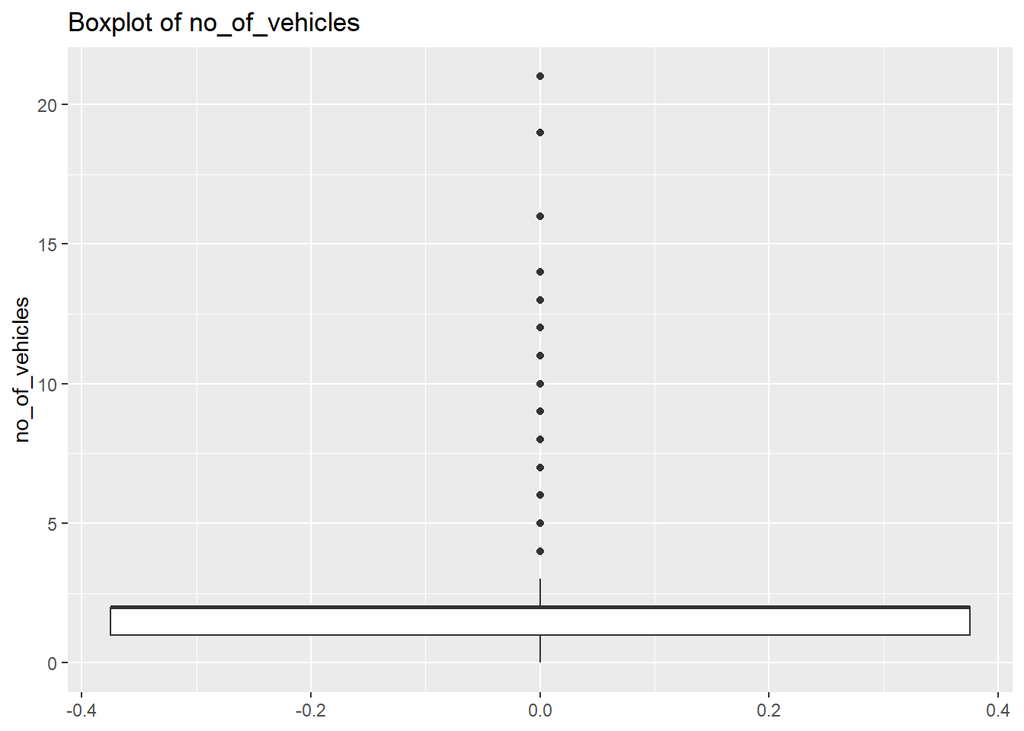

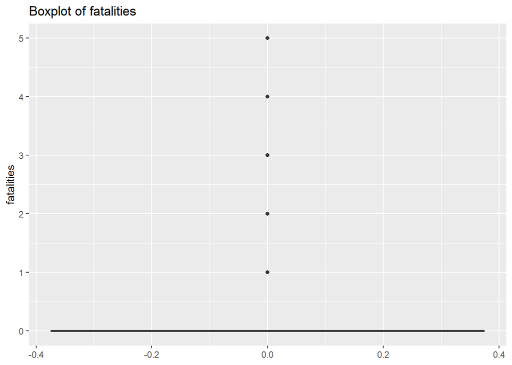

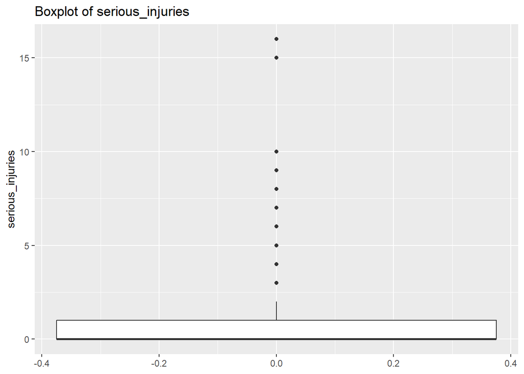

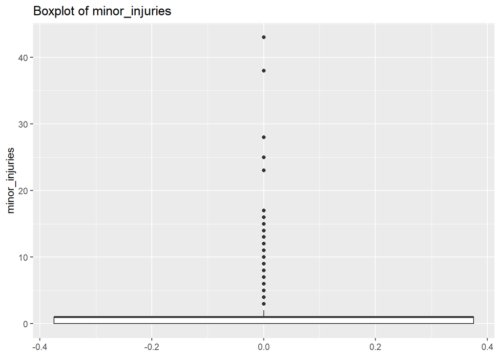

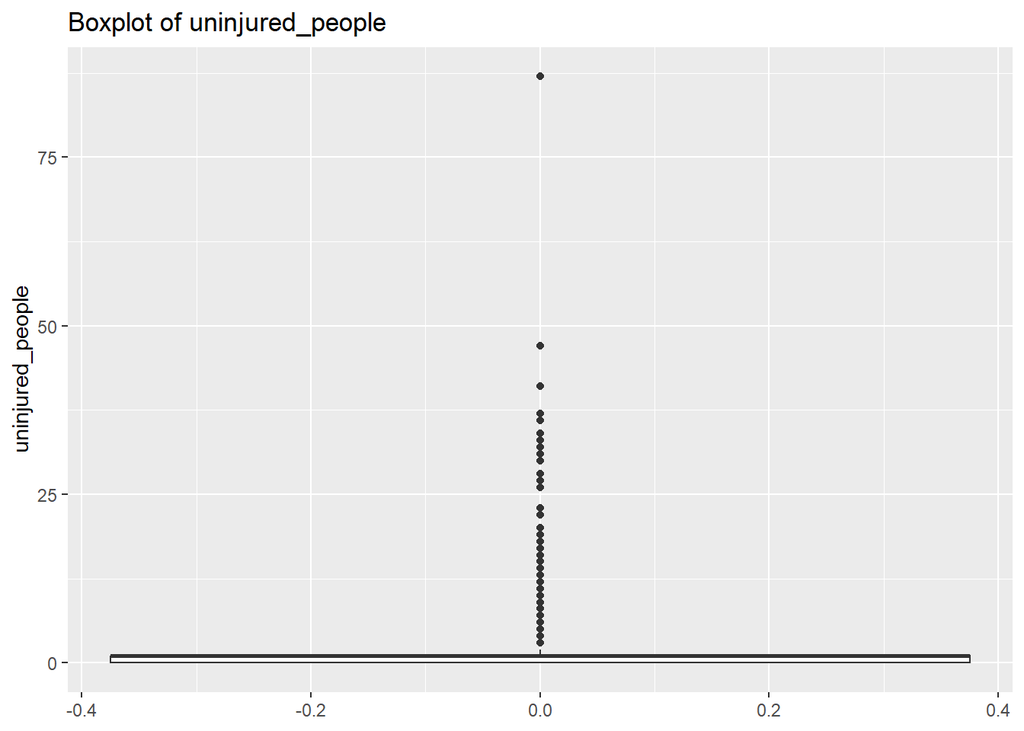

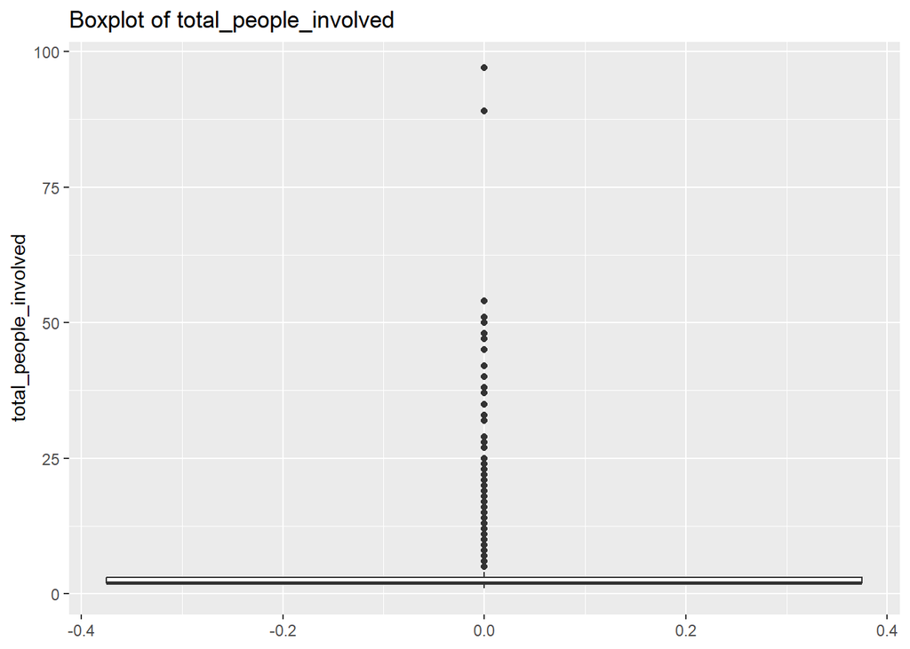

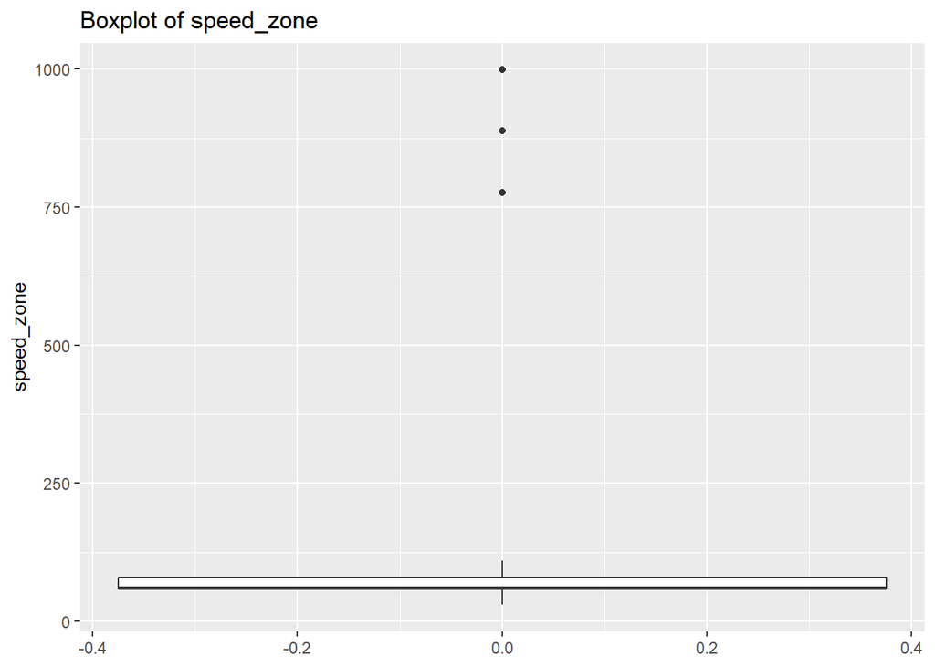

```r
# List of numeric variables:
numeric_vars <- c("no_of_vehicles", "fatalities", "serious_injuries",
                  "minor_injuries", "uninjured_people", "total_people_involved",
                  "speed_zone")

# Create a function to generate boxplots
create_boxplots <- function(data, variables) {
  for (var in variables) {
    p <- ggplot(data, aes_string(y = var)) +
      geom_boxplot() +
      labs(title = paste("Boxplot of", var), y = var)
    print(p)
  }
}

create_boxplots(merged_data, numeric_vars)
```

#### 7.1.1 Outlier Detection **‘no_of_vehicles’**:

```r
# Calculate Q1 (25th percentile) and Q3 (75th percentile):
Q1 <- quantile(merged_data$no_of_vehicles, 0.25, na.rm = TRUE)
Q3 <- quantile(merged_data$no_of_vehicles, 0.75, na.rm = TRUE)

# Calculate IQR (Interquartile Range)
IQR <- Q3 - Q1

# Define outlier fence:
lower_fence <- Q1 - 1.5 * IQR
upper_fence <- Q3 + 1.5 * IQR

# Print number of outliers:
cat("Lower Fence for Outliers:", lower_fence, "\n")
```

```
## Lower Fence for Outliers: -0.5
```

```r
cat("Upper Fence for Outliers:", upper_fence, "\n")
```

```
## Upper Fence for Outliers: 3.5
```

```r
# Find outliers:
outliers <- merged_data %>%
  filter(no_of_vehicles < lower_fence | no_of_vehicles > upper_fence)

# Count the number of outliers:
num_outliers <- nrow(outliers)
cat("Number of Outliers:", num_outliers, "\n")
```

```
## Number of Outliers: 4649
```

```r
# Analyse outliers:
summary(outliers$no_of_vehicles)
```

```
##    Min. 1st Qu.  Median    Mean 3rd Qu.    Max.
##   4.000   4.000   4.000   4.408   5.000  21.000
```

```r
outliers %<>%
  arrange(desc(no_of_vehicles))
head(outliers$no_of_vehicles)
```

```
## [1] 21 19 16 14 13 13
```

The values appear realistic, and no additional action is needed for the outliers in `merged_data$no_of_vehicles`.

We repeat similar analysis for other numeric variables:

#### 7.1.2 Outlier Detection **fatalities**:

```r
# Calculate Q1 (25th percentile) and Q3 (75th percentile):
Q1 <- quantile(merged_data$fatalities, 0.25, na.rm = TRUE)
Q3 <- quantile(merged_data$fatalities, 0.75, na.rm = TRUE)

# Calculate IQR (Interquartile Range)
IQR <- Q3 - Q1

# Define outlier fence:
lower_fence <- Q1 - 1.5 * IQR
upper_fence <- Q3 + 1.5 * IQR

# Print number of outliers:
cat("Lower Fence for Outliers:", lower_fence, "\n")
```

```
## Lower Fence for Outliers: 0
```

```r
cat("Upper Fence for Outliers:", upper_fence, "\n")
```

```
## Upper Fence for Outliers: 0
```

```r
# Find outliers:
outliers <- merged_data %>%
  filter(fatalities < lower_fence | fatalities > upper_fence)

# Count the number of outliers:
num_outliers <- nrow(outliers)
cat("Number of Outliers:", num_outliers, "\n")
```

```
## Number of Outliers: 2789
```

```r
# Analyse outliers:
summary(outliers$fatalities)
```

```
##    Min. 1st Qu.  Median    Mean 3rd Qu.    Max.
##   1.000   1.000   1.000   1.078   1.000   5.000
```

```r
outliers %<>%
  arrange(desc(fatalities))
head(outliers$fatalities)
```

```
## [1] 5 5 5 4 4 4
```

The values appear realistic, and no additional action is needed for the outliers in `merged_data$fatalities`.

#### 7.1.3 Outlier Detection **serious_injuries**

```r
# Calculate Q1 (25th percentile) and Q3 (75th percentile):
Q1 <- quantile(merged_data$serious_injuries, 0.25, na.rm = TRUE)
Q3 <- quantile(merged_data$serious_injuries, 0.75, na.rm = TRUE)

# Calculate IQR (Interquartile Range)
IQR <- Q3 - Q1

# Define outlier fence:
lower_fence <- Q1 - 1.5 * IQR
upper_fence <- Q3 + 1.5 * IQR

# Print number of outliers:
cat("Lower Fence for Outliers:", lower_fence, "\n")
```

```
## Lower Fence for Outliers: -1.5
```

```r
cat("Upper Fence for Outliers:", upper_fence, "\n")
```

```
## Upper Fence for Outliers: 2.5
```

```r
# Find outliers:
outliers <- merged_data %>%
  filter(serious_injuries < lower_fence | serious_injuries > upper_fence)

# Count the number of outliers:
num_outliers <- nrow(outliers)
cat("Number of Outliers:", num_outliers, "\n")
```

```
## Number of Outliers: 1467
```

```r
# Analyse outliers:
summary(outliers$serious_injuries)
```

```
##    Min. 1st Qu.  Median    Mean 3rd Qu.    Max.
##   3.000   3.000   3.000   3.462   4.000  16.000
```

```r
outliers %<>%
  arrange(desc(serious_injuries))
head(outliers$serious_injuries)
```

```
## [1] 16 15 10  9  8  8
```

The values appear realistic, and no additional action is needed for the outliers in `merged_data$serious_injuries`.

#### 7.1.4 Outlier Detection **minor_injuries**

```r
# Calculate Q1 (25th percentile) and Q3 (75th percentile):
Q1 <- quantile(merged_data$minor_injuries, 0.25, na.rm = TRUE)
Q3 <- quantile(merged_data$minor_injuries, 0.75, na.rm = TRUE)

# Calculate IQR (Interquartile Range)
IQR <- Q3 - Q1

# Define outlier fence:
lower_fence <- Q1 - 1.5 * IQR
upper_fence <- Q3 + 1.5 * IQR

# Print number of outliers:
cat("Lower Fence for Outliers:", lower_fence, "\n")
```

```
## Lower Fence for Outliers: -1.5
```

```r
cat("Upper Fence for Outliers:", upper_fence, "\n")
```

```
## Upper Fence for Outliers: 2.5
```

```r
# Find outliers:
outliers <- merged_data %>%
  filter(minor_injuries < lower_fence | minor_injuries > upper_fence)

# Count the number of outliers:
num_outliers <- nrow(outliers)
cat("Number of Outliers:", num_outliers, "\n")
```

```
## Number of Outliers: 5150
```

```r
# Analyse outliers:
summary(outliers$minor_injuries)
```

```
##    Min. 1st Qu.  Median    Mean 3rd Qu.    Max.
##   3.000   3.000   3.000   3.541   4.000  43.000
```

```r
outliers %<>%
  arrange(desc(minor_injuries))
head(outliers$minor_injuries)
```

```
## [1] 43 38 28 25 23 23
```

The values appear realistic, and no additional action is needed for the outliers in `merged_data$minor_injuries`.

#### 7.1.5 Outlier Detection **uninjured_people**

```r
# Calculate Q1 (25th percentile) and Q3 (75th percentile):
Q1 <- quantile(merged_data$uninjured_people, 0.25, na.rm = TRUE)
Q3 <- quantile(merged_data$uninjured_people, 0.75, na.rm = TRUE)

# Calculate IQR (Interquartile Range)
IQR <- Q3 - Q1

# Define outlier fence:
lower_fence <- Q1 - 1.5 * IQR
upper_fence <- Q3 + 1.5 * IQR

# Print number of outliers:
cat("Lower Fence for Outliers:", lower_fence, "\n")
```

```
## Lower Fence for Outliers: -1.5
```

```r
cat("Upper Fence for Outliers:", upper_fence, "\n")
```

```
## Upper Fence for Outliers: 2.5
```

```r
# Find outliers:
outliers <- merged_data %>%
  filter(uninjured_people < lower_fence | uninjured_people > upper_fence)

# Count the number of outliers:
num_outliers <- nrow(outliers)
cat("Number of Outliers:", num_outliers, "\n")
```

```
## Number of Outliers: 13850
```

```r
# Analyse outliers:
summary(outliers$uninjured_people)
```

```
##    Min. 1st Qu.  Median    Mean 3rd Qu.    Max.
##    3.00    3.00    3.00    3.89    4.00   87.00
```

```r
outliers %<>%
  arrange(desc(uninjured_people))
head(outliers$uninjured_people)
```

```
## [1] 87 87 47 41 41 41
```

The values appear realistic, and no additional action is needed for the outliers in `merged_data$uninjured_people`.

#### 7.1.6 Outlier Detection **total_people_involved**

```r
# Calculate Q1 (25th percentile) and Q3 (75th percentile):
Q1 <- quantile(merged_data$total_people_involved, 0.25, na.rm = TRUE)
Q3 <- quantile(merged_data$total_people_involved, 0.75, na.rm = TRUE)

# Calculate IQR (Interquartile Range)
IQR <- Q3 - Q1

# Define outlier fence:
lower_fence <- Q1 - 1.5 * IQR
upper_fence <- Q3 + 1.5 * IQR

# Print number of outliers:
cat("Lower Fence for Outliers:", lower_fence, "\n")
```

```
## Lower Fence for Outliers: 0.5
```

```r
cat("Upper Fence for Outliers:", upper_fence, "\n")
```

```
## Upper Fence for Outliers: 4.5
```

```r
# Find outliers:
outliers <- merged_data %>%
  filter(total_people_involved < lower_fence | total_people_involved > upper_fence)

# Count the number of outliers:
num_outliers <- nrow(outliers)
cat("Number of Outliers:", num_outliers, "\n")
```

```
## Number of Outliers: 11026
```

```r
# Analyse outliers:
summary(outliers$total_people_involved)
```

```
##    Min. 1st Qu.  Median    Mean 3rd Qu.    Max.
##   5.000   5.000   5.000   6.106   6.000  97.000
```

```r
outliers %<>%
  arrange(desc(total_people_involved))
head(outliers$total_people_involved)
```

```
## [1] 97 89 54 51 50 48
```

The values appear realistic, and no additional action is needed for the outliers in `merged_data$total_people_involved`.

#### 7.1.7 Outlier Detection **speed_zone**:

In this section, we will compare the number of rows in the dataset before and after the removal of outliers in the speed_zone variable. We will also summarize the changes.

```r
# Calculate Q1 (25th percentile) and Q3 (75th percentile):
Q1 <- quantile(merged_data$speed_zone, 0.25, na.rm = TRUE)
Q3 <- quantile(merged_data$speed_zone, 0.75, na.rm = TRUE)

# Calculate IQR (Interquartile Range)
IQR <- Q3 - Q1

# Define outlier fence:
lower_fence <- Q1 - 1.5 * IQR
upper_fence <- Q3 + 1.5 * IQR

# Print number of outliers:
cat("Lower Fence for Outliers:", lower_fence, "\n")
```

```
## Lower Fence for Outliers: 30
```

```r
cat("Upper Fence for Outliers:", upper_fence, "\n")
```

```
## Upper Fence for Outliers: 110
```

```r
# Find outliers:
outliers <- merged_data %>%
  filter(speed_zone < lower_fence | speed_zone > upper_fence)

# Count the number of outliers:
num_outliers <- nrow(outliers)
cat("Number of Outliers:", num_outliers, "\n")
```

```
## Number of Outliers: 12140
```

```r
# Examine outliers
print(table(outliers$speed_zone))
```

```
##
##   777   888   999
##   308  1055 10777
```

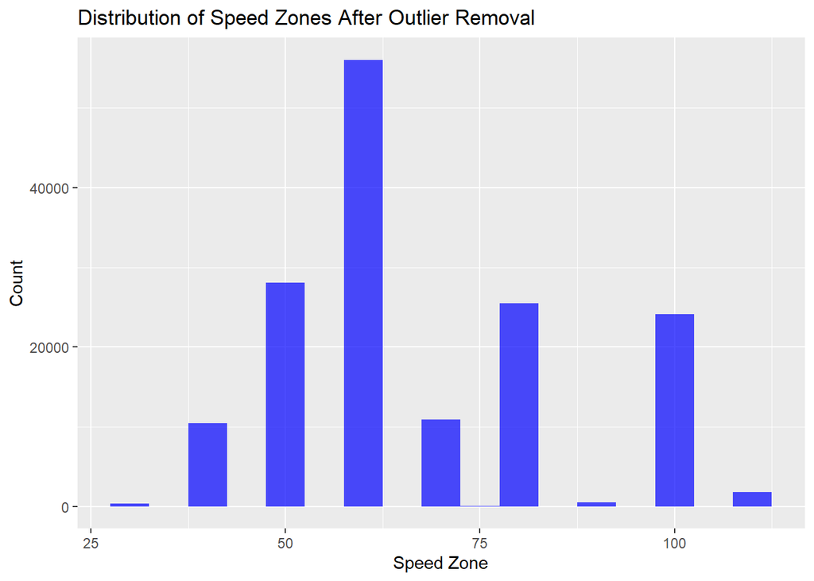

```r
# Remove outliers
merged_data_clean <- merged_data %>%
  filter(speed_zone >= lower_fence & speed_zone <= upper_fence)
# 7. Visualize the speed_zone distribution after removing outliers
ggplot(merged_data_clean, aes(x = speed_zone)) +
  geom_histogram(binwidth = 5, fill = "blue", alpha = 0.7) +
  labs(title = "Distribution of Speed Zones After Outlier Removal",
       x = "Speed Zone", y = "Count")
```

```r
# 8. Compare before and after
cat("Rows before outlier removal:", nrow(merged_data), "\n")
```

```
## Rows before outlier removal: 169877
```

```r
cat("Rows after outlier removal:", nrow(merged_data_clean), "\n")
```

```
## Rows after outlier removal: 157737
```

```r
cat("Rows removed:", nrow(merged_data) - nrow(merged_data_clean), "\n")
```

```
## Rows removed: 12140
```

```r
# 9. Summary of clean data
summary(merged_data_clean$speed_zone)
```

```
##    Min. 1st Qu.  Median    Mean 3rd Qu.    Max.
##   30.00   60.00   60.00   67.54   80.00  110.00
```

```r
merged_data <- merged_data_clean
```

For the `speed_zone` variable, we identified outliers above 110 km/h. These values are inconsistent with Victoria’s standard speed limits. We removed a total of 12140 outliers as they likely represent data entry errors.

For all other outliers, we chose to retain them. Despite their appearance as outliers on the boxplot, these values remain realistic. This is because, in most accidents, the number of vehicles or persons involved is typically low, which aligns with the observed data distribution.

## 8. Transform the Data

In this section, we will explore the distribution of numeric variables and apply transformations to normalize the data if necessary.

#### 8.1 Histogram Visualization

We will plot histograms for the total_casualties and no_of_vehicles columns before and after applying a log transformation.

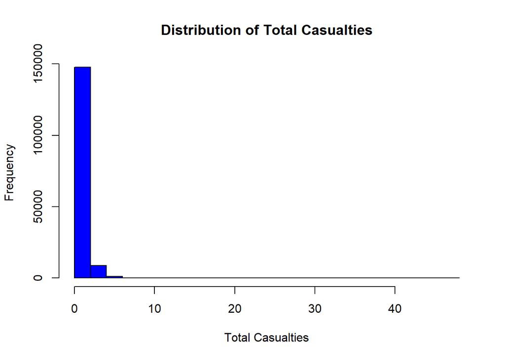

```r
# Create histograms for 'total_casualties' before and after log transformation

# Original distribution of 'total_casualties'
p1<- hist(merged_data$total_casualties,
     breaks = 30,
     main = "Distribution of Total Casualties",
     xlab = "Total Casualties",
     col = "blue",
     border = "black")
```

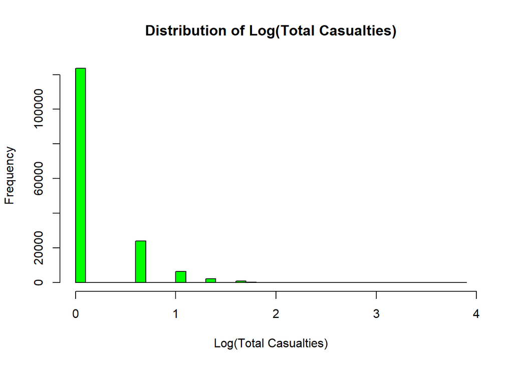

```r
# Distribution of log-transformed 'total_casualties'
p2<- hist(log(merged_data$total_casualties),
     breaks = 30,
     main = "Distribution of Log(Total Casualties)",
     xlab = "Log(Total Casualties)",
     col = "green",
     border = "black")
```

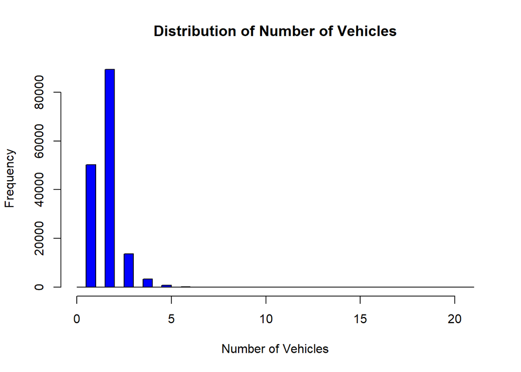

```r
# Create histograms for 'no_of_vehicles' before and after log transformation

# Original distribution of 'no_of_vehicles'
p1<- hist(merged_data$no_of_vehicles,
     breaks = 30,
     main = "Distribution of Number of Vehicles",
     xlab = "Number of Vehicles",
     col = "blue",
     border = "black")
```

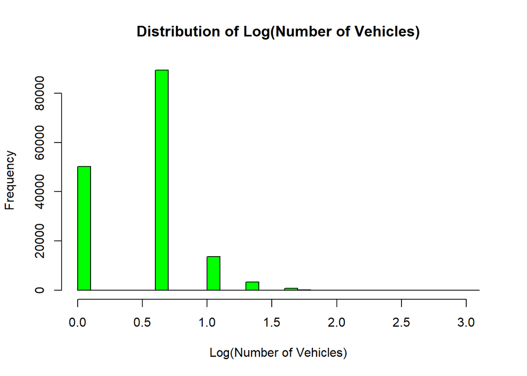

```r
# Distribution of log-transformed 'no_of_vehicles'
p2<- hist(log(merged_data$no_of_vehicles),
     breaks = 30,
     main = "Distribution of Log(Number of Vehicles)",
     xlab = "Log(Number of Vehicles)",
     col = "green",
     border = "black")
```

## 10. References

[01]Department of Transport (2024) *Victoria Road Crash Data*, Discover Victoria’s Open Data website, accessed 8 August 2024. https://discover.data.vic.gov.au/dataset/victoria-road-crash-data

[02]Iglewicz B, Hoaglin DC (1993) How to detect and handle outliers, Wiley, New York.